# Where is the Money for Feminist Organizing? Survey for feminist, women’s rights and gender justice movements, groups and organizations

2024-07-10

#WITM follow up

**Database upload**

```r
# To upload CSV file
witm <- read.csv2("Data/WITM_csv_0710.csv")

#2024-05-23 08:37:41.178000-04:00
witm$date <-  as.Date(witm$end,'%Y-%m-%d')


#names(witm)
# To upload xlsx file
#datos<- read_xlsx("WITM_xls_value2.xlsx", sheet = 1)
```

**Number of answers by date**

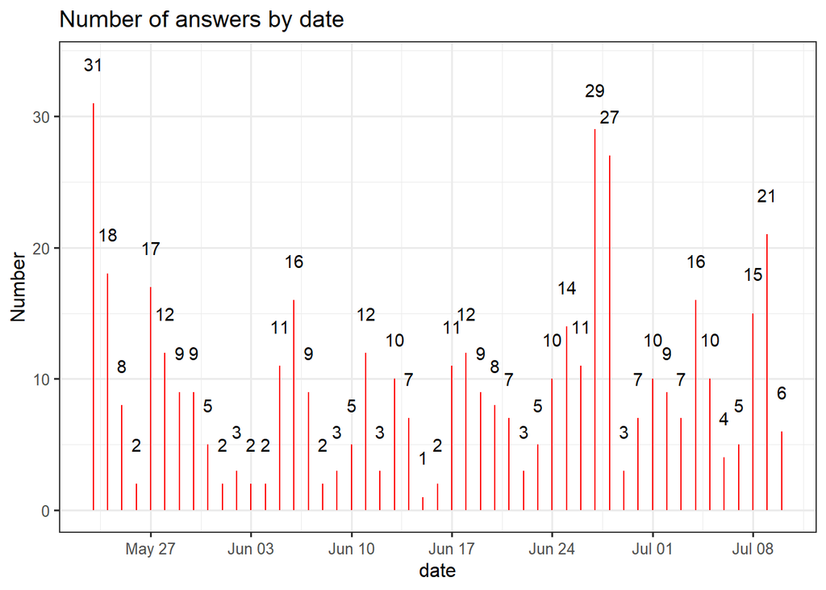

**–Analysis notes———————————————————————–**

In general the polls always have a high peak on the first day, WITM also shows this. Then there is another spike on 27-28 June, probably a strengthening of communication. On the 4th of July it increases again.

**————————————————————————————————**

**Consent:**

Q1. I consent to take the WITM survey on behalf of my group, organization or movement.

| Consent | n | porcentaje |
| --- | --- | --- |
| no | 22 | 4.8 |
| yes | 438 | 95.2 |

**Group information:**

Q2. Which of the following statements best describes your group, organization and/or movement?

| Description | n | porcentaje |
| --- | --- | --- |
| We promote the rights of women or girls or trans or gender diverse people with intersecting identities ‘through specific project(s)’, but not as the primary focus of our work | 69 | 15.8 |
| We promote the rights of women or girls or trans or gender diverse people in all their intersecting identities and this is the ‘primary focus of all our work’ | 335 | 76.5 |
| Other | 34 | 7.8 |

| Other |
| --- |
| 10%of my work |
| Dans le cadre de la lutte contre les VBG |
| Every woman should be treated with respect and their dignity should be respected as well |
| Girls and women with Disabilities |
| Ils sont pris en compte dès l’élaboration de nos plans d’actions jusqu’à l’exécution de nos actions et activités. |
| In our case management portfolio for SGBV and Child Protection and Children/adult safeguarding, we offer care to all who need it nonjudgmentally. |
| Labour rights |
| Niñas, jóvenes y mujeres adultas con discapacidad |
| Nous promovons cadres d’expression et de militantisme des femmes pour les DHs et contre VSBG |
| Prevention and visibility of women living with HIV and their rights |
| Promovemos la defensa de los derechos sexuales y derechos reproductivos de las mujeres, niñas y de las personas con capacidad de gestar |
| Promovemos los Derechos de las Mujeres Trans Migrantes |
| Rural Women Empowerment Organization is most working to protect the right of the most vulnerable groups in South Sudan. |
| Somos una organización de Mujeres Indígenas YUKPA, con perspectiva de género y localizada en la comunidad, inclusiva, interseccional |
| We advocate for gender inclusive trade rights for women and youth. |
| We promote the rights of women or girls in trade in the cross borders |
| We promote community-led leadership of women and girls to live with dignity and take stand against violence and discrimination. |
| We promote links and partnerships between religiously-identified women who identify as feminists and feminist organisations to combat fundamentalism. |
| We promote the right of women n girls wo was living with hiv for their feminist right |
| We promote the rights and the resourcing of women / girls / trans / gender diverse people |
| We promote the rights of vulnerable children and their families including Mbororo minority, and those with disability |
| We promote the rights of women and girls with disabilities in all our intersecting identities and this the primary focus of all our work. |
| We promote the rights of women or girls from next population: LBT, living with HIV+, sex workers, pacients, young, Roma. |
| We promote the rights of women with disabilities in all in Timor - Leste |
| We promote the rights of women, girls and vulnerable people through specific projects, as the primary focus of our work. |
| We promote the rioghts of women and girls in all their diversity to influence leadership and governance, and peace processes. |
| We work for women who use drugs and intersectional groups among WUD we advocate for right to health & human rights, SRH services beyond HIV |
| We work with women with disabilities. |
| Women’s rights are human rights and alla human being are equal in human right, human rights are universal, interconnected and inalienable |
| ce n’est pas une priorité de notre travail. nous travaillons pour l’autonomisation, le leadership et les droits des femmes |
| we promote rights of women and girls with disabilities in the continent of Africa |
| we support the rights of women and girls of a life without sexual violence |
| women and girls with disabilities |
| النساء و الفتيات ضحايا العنف طبق احكام القانون الاساسي التونسي عدد58 المؤرخ في اوت2017 |

**Organization names:**

Q3. The name of your group, organization and/or movement

```
## [1] "The number of organisations that did not answer their name is: 29"
```

**–Analysis notes———————————————————————–**

Very interesting that almost all organisations responded with their name despite the fact that the possibility of not responding is informed and underlined.

**————————————————————————————————**

**Type of organization**

Q4. Which of the following forms of organizing best describes your group, organization and/or movement?

*This is a multiple-choice question so the sum of the % does NOT add up to 100.*

| Organization type | n | porcentaje |
| --- | --- | --- |
| Women’s rights | 343 | 78.3 |
| Ending gender based violence | 299 | 68.3 |
| Human rights | 259 | 59.1 |
| Sexual and reproductive health & rights (SRHR) and bodily autonomy | 248 | 56.6 |
| Young feminists | 163 | 37.2 |
| Human rights defenders at risk | 151 | 34.5 |
| Economic justice, rights and alternatives | 147 | 33.6 |
| Climate and environmental justice | 140 | 32.0 |
| Disability rights and justice | 124 | 28.3 |
| Girls’ movements | 121 | 27.6 |
| Lesbian, Bisexual and queer rights | 112 | 25.6 |
| Sex workers rights | 107 | 24.4 |
| Countering anti-gender and anti-rights | 97 | 22.1 |
| Rights for people living with HIV+ | 96 | 21.9 |
| Indigenous rights | 93 | 21.2 |
| Displaced, migrant and refugee rights | 92 | 21.0 |
| Trans and non-binary rights | 83 | 18.9 |
| Holistic safety, protection and collective care | 82 | 18.7 |
| Labour rights | 82 | 18.7 |
| Crisis response | 81 | 18.5 |
| Digital rights | 76 | 17.4 |
| Freedom of information and media | 63 | 14.4 |
| Racial justice | 61 | 13.9 |
| Black rights/ Black feminist rights | 58 | 13.2 |
| Harm reduction | 55 | 12.6 |
| Pleasure and bodily care | 54 | 12.3 |
| Intersex rights | 48 | 11.0 |
| Anti-militarization and peace | 45 | 10.3 |
| Religious and ethnic minority rights | 38 | 8.7 |
| Other | 23 | 5.3 |
| Resisting the war on drugs | 22 | 5.0 |
| Anti-caste | 15 | 3.4 |

**–Analysis notes———————————————————————–**

Most of the organisations selected many options. Almost all of them defined one of the first three options. Only 10% did not select any of them and in general selected others that can be integrated.

**————————————————————————————————**

**Type of organization - grouping**

In order to make it easier to analyse, groups can be made, but they are not mutually exclusive, so they are still multiple options.

THIS CAN BE DEFINED DIFFERENTLY. POSSIBLE GROUPINGS SHOULD BE INDICATED

**Feminist specifit subjects** Girls’ movements. Young feminists . Countering anti-gender and anti-rights Lesbian, Bisexual and queer rights Sex workers rights Trans and non-binary rights Intersex rights

**General HR subjects** Human rights defenders at risk Economic justice, rights and alternatives Climate and environmental justice Anti-militarization and peace Crisis response Resisting the war on drugs Anti-caste Digital rights Freedom of information and media

**Intersectionality (minority groups)** Disability rights and justice Displaced, migrant and refugee rights Indigenous rights Racial justice Black rights/ Black feminist rights Religious and ethnic minority rights

**Sexual and reproductive health & rights (and others health rights)** Rights for people living with HIV+ Holistic safety, protection and collective care Pleasure and bodily care Sexual and reproductive health & rights (SRHR) and bodily autonomy

| Organization grouped type | n | porcentaje |
| --- | --- | --- |
| General HR subjects | 312 | 71.2 |
| Feminist specifit subjects | 296 | 67.6 |
| Sexual and reproductive health & rights (and othershealth rights) | 286 | 65.3 |
| Intersectionality (minority groups) | 231 | 52.7 |

**Organisation type & focused**

| q1_description | total | Specific feminist subjects | General HR Subjects | Intersectionality (minority groups) | Sexual and reproductive health & rights |
| --- | --- | --- | --- | --- | --- |
| specific_projects | 69 | 62.32 | 73.91 | 50.72 | 62.32 |
| primary_focus | 335 | 69.55 | 70.15 | 51.94 | 66.87 |
| 98 | 34 | 58.82 | 76.47 | 64.71 | 55.88 |

**–Analysis notes———————————————————————–**

As this is a multiple choice question, each row is read independently.

**————————————————————————————————**

**Register**

Q5. Is your group, organization and/or movement registered?

| Register | n | porcentaje |
| --- | --- | --- |
| Yes | 358 | 81.7 |
| No | 65 | 14.8 |
| Other | 12 | 2.7 |
| NA | 3 | 0.7 |

**Register by type of organisation**

```
## # A tibble: 8 × 3
## # Groups:   q1_description [3]
##   q1_description    q5_registered percentage
##   <chr>             <chr>              <dbl>
## 1 primary_focus     y_registered        81.3
## 2 specific_projects y_registered        88.4
## 3 primary_focus     n_registered        15.4
## 4 98                y_registered        79.4
## 5 primary_focus     98                   3.3
## 6 specific_projects n_registered        11.6
## 7 98                n_registered        17.6
## 8 98                98                   2.9
```

| q5_registered | primary_focus | specific_projects | 98 |
| --- | --- | --- | --- |
| y_registered | 81.3 | 88.4 | 79.4 |
| n_registered | 15.4 | 11.6 | 17.6 |
| 98 | 3.3 | NA | 2.9 |

**Register by subject or area**

+++++++REVISAR no esta OK el cruce+++

| q5_registered | total | fem | hr | min | srhr | Specific feminist subjects | General HR Subjects | Intersectionality (minority groups) | Sexual and reproductive health & rights |
| --- | --- | --- | --- | --- | --- | --- | --- | --- | --- |
| y_registered | 358 | 235 | 257 | 193 | 235 | 65.64 | 71.79 | 53.91 | 65.64 |
| n_registered | 65 | 49 | 47 | 31 | 43 | 75.38 | 72.31 | 47.69 | 66.15 |
| 98 | 12 | 9 | 6 | 5 | 7 | 75.00 | 50.00 | 41.67 | 58.33 |
|  | 3 | 3 | 2 | 2 | 1 | 100.00 | 66.67 | 66.67 | 33.33 |

**–Analysis notes———————————————————————–**

It is more common to find unregistered feminist organizations than those that address gender issues through specific projects. It is necessary to verify whether this trend continues

**————————————————————————————————**

**Scope:**

Q6. What is the geographical scope of your work?

| Geo scope | n | porcentaje |
| --- | --- | --- |
| Work from diaspora, refuge and/or exile | 4 | 0.9 |
| Global | 28 | 6.4 |
| Locally | 131 | 29.9 |
| Nationally | 225 | 51.4 |
| Regionally | 44 | 10.0 |
| Transnationally | 6 | 1.4 |

**Region:**

Q7. Indicate in which region(s) your group, organization and/or movement works

| Region | n | porcentaje |
| --- | --- | --- |
| South Asia | 85 | 55.6 |
| South America | 70 | 45.8 |
| East Africa | 68 | 44.4 |
| West Africa | 67 | 43.8 |
| Central America & Mexico | 49 | 32.0 |
| Southeast Asia | 45 | 29.4 |
| Central Africa | 40 | 26.1 |
| Eastern Europe, Southeast Europe and Central Europe | 36 | 23.5 |
| Southern Africa | 29 | 19.0 |
| South West Asia/Middle East | 29 | 19.0 |
| Western Europe | 28 | 18.3 |
| North Africa | 26 | 17.0 |
| The Pacific | 22 | 14.4 |
| Caribbean | 17 | 11.1 |
| North America | 15 | 9.8 |
| East Asia | 13 | 8.5 |
| Central Asia & Caucasus | 9 | 5.9 |

**Country:**

**Year of formation:**

Q9. What year was your group, organization and/ or movement formed?

| Year formation | total | porcentaje |
| --- | --- | --- |
| Año 2023 | 22 | 5.0 |
| Año 2022 | 25 | 5.7 |
| Año 2021 | 18 | 4.1 |
| Entre 2015 y 2020 | 141 | 32.2 |
| Entre 2010 y 2014 | 71 | 16.2 |
| Entre 2000 y 2009 | 105 | 24.0 |
| Antes del 2000 | 56 | 12.8 |

**External founding:**

Q13. Between 2021 and 2023, has your group, organization and/or movement received any external funding?

| External funding | n | porcentaje |
| --- | --- | --- |
| no | 122 | 27.9 |
| yes | 316 | 72.1 |

**Language:**

Q46. In which language did you answer the survey?

| Language | n | porcentaje |
| --- | --- | --- |
| Arabic | 10 | 2.3 |
| English | 246 | 56.2 |
| French | 51 | 11.6 |
| Portuguese | 5 | 1.1 |
| Russian | 4 | 0.9 |
| Spanish | 64 | 14.6 |
| NA | 58 | 13.2 |

Q45. Did anyone from your group, organization and/or movement respond to AWID’s Where is the Money survey in 2008 or 2011?

| Previous response | n | porcentaje |
| --- | --- | --- |
| Yes | 43 | 9.8 |
| No | 313 | 71.5 |
| Don’t know | 82 | 18.7 |